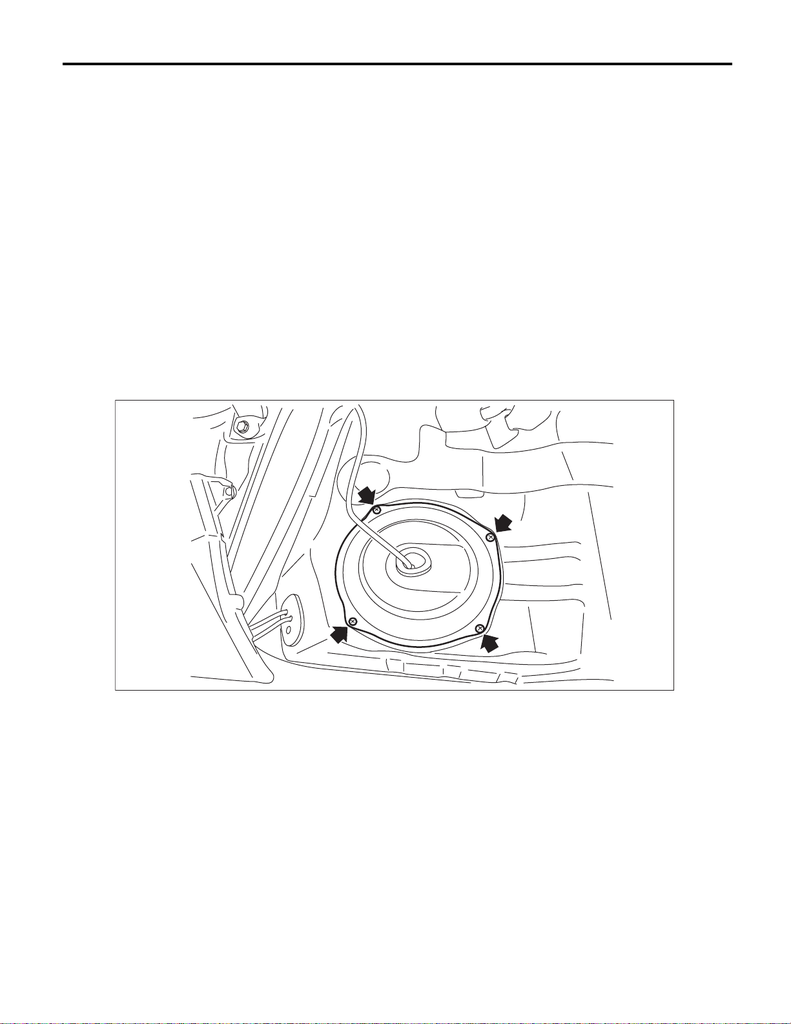

FU(w/o STI)-168

Fuel Pump

FUEL INJECTION (FUEL SYSTEMS)

36.Fuel Pump

A: REMOVAL

WARNING:

Place “NO OPEN FLAMES” signs near the working area.

CAUTION:

• Be careful not to spill fuel.

• Catch the fuel from the tubes using a container or cloth.

• If the fuel gauge indicates that two thirds or more of the fuel is remaining, be sure to drain fuel be-

fore starting work to avoid the fuel to spill.

NOTE:

Fuel pump assembly consists of fuel pump, fuel filter and fuel level sensor.

1) Release the fuel pressure. <Ref. to FU(w/o STI)-146, RELEASING OF FUEL PRESSURE, PROCE-

DURE, Fuel.>

2) Drain fuel. <Ref. to FU(w/o STI)-146, DRAINING FUEL (WITH SUBARU SELECT MONITOR), PROCE-

DURE, Fuel.>

3) Disconnect the ground terminal from battery sensor. <Ref. to NT-5, BATTERY, NOTE, Note.>

4) Remove the rear seat cushion. <Ref. to SE-29, REMOVAL, Rear Seat.>

5) Remove the service hole cover of fuel pump.

FU-06417

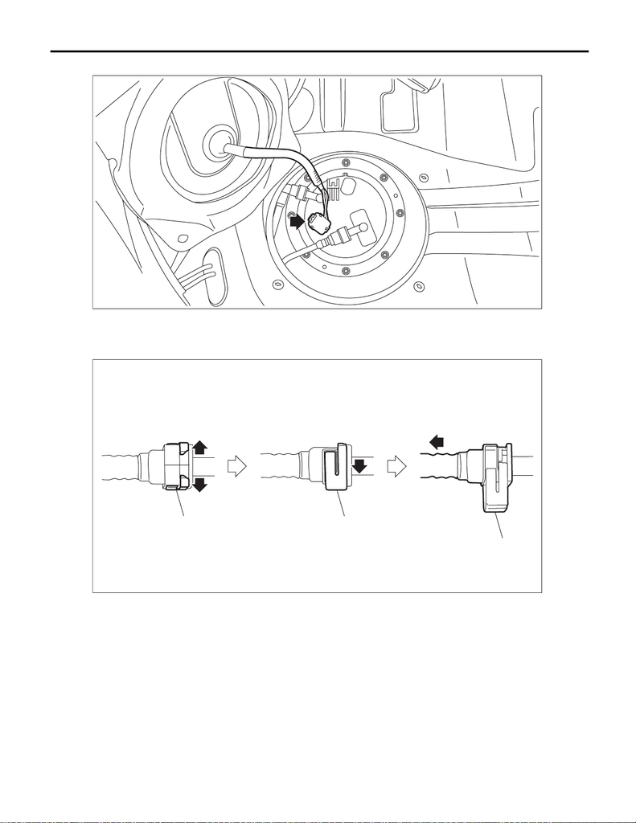

FU(w/o STI)-169

Fuel Pump

FUEL INJECTION (FUEL SYSTEMS)

6) Disconnect connectors from the fuel pump, and move aside the service hole cover.

7) Disconnect the quick connector of fuel delivery tube and jet pump tube.

NOTE:

Disconnect the quick connector as shown in the figure.

(a) Slider

FU-07694

EC-02771

(a)

(a)

(a)

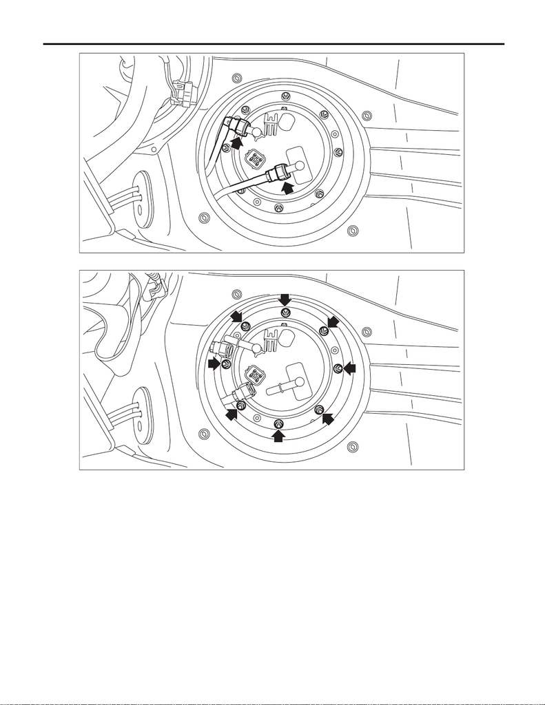

FU(w/o STI)-170

Fuel Pump

FUEL INJECTION (FUEL SYSTEMS)

8) Remove the nuts which hold the fuel pump upper plate to the fuel tank.

9) Remove the fuel pump assembly from the fuel tank.

CAUTION:

Be careful not to let the arm and float of fuel level sensor contact the fuel tank.

FU-07705

FU-07706

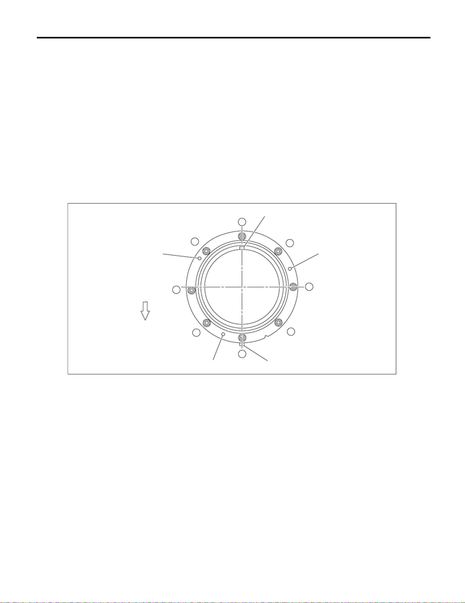

FU(w/o STI)-171

Fuel Pump

FUEL INJECTION (FUEL SYSTEMS)

B: INSTALLATION

Install in the reverse order of removal while being careful of the following.

CAUTION:

Set the arm and float of the fuel level sensor while paying attention to prevent them from contacting

the fuel tank. If the arm of the fuel level sensor is bent, the fuel gauge may not read correctly.

• Make sure the sealing portion is free from fuel or foreign matter before installation.

• Align protrusion (A) of the gasket to the position shown in the figure.

• Align the protrusion (C) of fuel pump upper plate cushion with the protrusion (C) of fuel pump assembly.

• Align the protrusion (C) of fuel pump upper plate cushion with the cutout on the fuel pump upper plate.

• Insert the protrusion (B) of gasket to the fuel pump upper plate. (3 places)

• Tighten the nuts to the specified torque in the order as shown in the figure.

NOTE:

Use a new gasket.

Tightening torque:

4.4 N·m (0.4 kgf-m, 3.2 ft-lb)

(a) Front side of vehicle

1

2

3

4

5

6

7

8

(C)

(B)

(B)

(B)

(A)

(a)

FU-06047

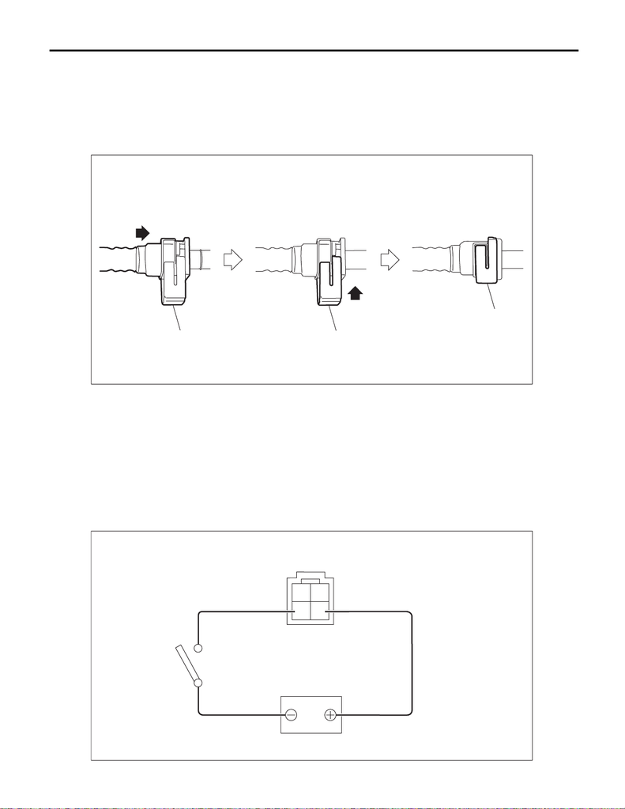

FU(w/o STI)-172

Fuel Pump

FUEL INJECTION (FUEL SYSTEMS)

• Connect the quick connector as shown in the figure.

CAUTION:

• Check that there is no damage or dust on the quick connector. If necessary, clean the seal sur-

face of the pipe.

• When connecting the quick connector, make sure to insert it all the way in before locking the slider.

• When it is difficult to lock the slider, check that the connector is fully inserted.

• After locking the slider, check again that the quick connector is securely connected.

C: INSPECTION

1) Check that the fuel pump has no deformation, cracks or other damages.

2) Connect the battery positive terminal to terminal No. 3 and the battery ground terminal to terminal No. 4,

and inspect the fuel pump operation.

WARNING:

• Wipe off fuel completely.

• Keep the battery as far apart from fuel pump as possible.

• Do not run the fuel pump for a long time under non-load condition.

(a) Slider

EC-02779

(a)

(a)

(a)

21

43

FU-07775